# Activity Analysis (Final Submission)

Konrad Zdeb

19th July 2014

# Getting the Data

## Sourcing the data

The code below checks whether the required data files exists in the working directory and if the file doesn’t exists it attempts to source the the zip file and unzip it. The Last bits of code remove objects that were created for the purpose of getting the data. If the CSV file is available in the working directory there is no need to run the code in this section and the one can progress to the section on reading data.

```r
# I'm using the RCurl package to download the file if not saved in the directory
# The code below will install it if not available
if (!require("RCurl",character.only = TRUE))
    {
      install.packages("RCurl",dep=TRUE)
        if(!require("RCurl",character.only = TRUE)) stop("Package not found.
                                                          Please make sure that
                                                          you have the Lattice
                                                          package installed")
    }
```

```r
# Now i check whether the data exists and download if it doesn't exists
if (!file.exists("activity.csv")) {
        # Check wthether the zip archive is available.
        if (!file.exists("repdata_data_activity.zip")) {
                # Define data source.
                dataurl <- "https://d396qusza40orc.cloudfront.net/repdata%2Fdata%2Factivity.zip"
                # Download, save and unzip the file.
                library(RCurl)
                bin <- getBinaryURL(dataurl, ssl.verifypeer=FALSE,
                                    noprogress = FALSE)
                con <- file("repdata_data_activity.zip",
                            open = "wb")
                writeBin(bin, con)
                close(con)
                unzip("repdata_data_activity.zip")
        } else
                unzip("repdata_data_activity.zip")
}
file <- list.files(path=getwd(), pattern = "activity.csv", all.files = TRUE,
                    recursive = TRUE, full.names = TRUE)
# Clean redundant objects after download
if (exists("bin")) rm(bin)
if (exists("con")) rm(con)
if (exists("dataurl")) rm(dataurl)
```

## Reading Data

The code reads and prepares the data. The date column is translated to the R date format.

```r
# Read the file
act.dta <- read.csv(file = file)
#Change date to the R date format
act.dta$date <- as.Date(act.dta$date, "%Y-%m-%d")
```

# Analysis

The sections here correspond to the questions in the assignment with each section answering one of the requests. It assumed that the master data is available in the act.dta file, if the data is not available or object is renamed the code below can be run to create the master data file with the required file.

## Setps per Day

The section is concerned with answering the first question *What is mean total number of steps taken per day?*

### Histogram

The code below generates the requested histogram. I added nice curve to make it more interesting.

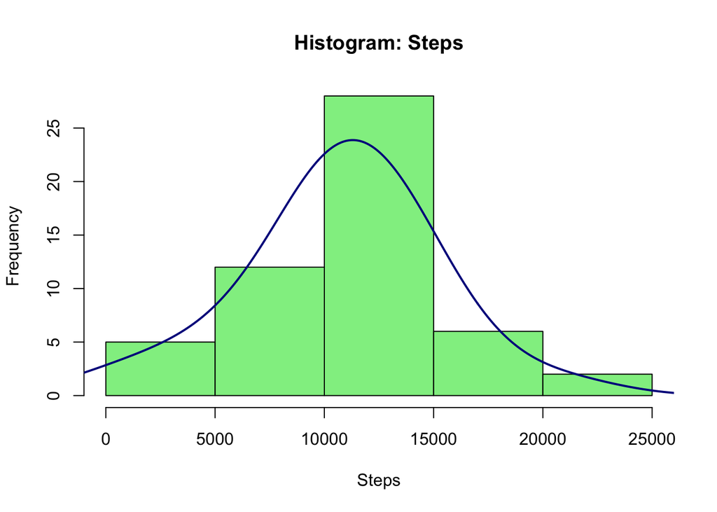

```r
# Create values with sum of steps per day
act.dta.sum <- aggregate(x = act.dta[c("steps")], FUN = sum,
                         by = list(date = act.dta$date))
# Create histogram
stepshist <- hist(x = act.dta.sum$steps, plot = FALSE)
# Create nice normal curve
multiplier <- stepshist$counts / stepshist$density
stpsdnst <- density(act.dta.sum$steps, na.rm = TRUE, adjust = 2)
stpsdnst$y <- stpsdnst$y * multiplier[1]
# Plot both graphics
plot(stepshist, main = "Histogram: Steps", xlab = "Steps", col="lightgreen")
lines(stpsdnst, col="darkblue", lwd=2)
```

### Mean and Median Steps

The code below calculates and reports mean and median steps using the summary data for the steps. Following [the discussion](https://class.coursera.org/repdata-004/forum/thread?thread_id=25) on the course forum the utilised syntax assumes that we are obtaining one mean and one one median for the total steps per day.

```r
# Force R not to use scientific notation, and keep two decimal places.
options("scipen"=100, "digits"=4)
options(digits=2)
# Obtain mean
mean(act.dta.sum$steps, na.rm = TRUE)
```

```
## [1] 10766
```

```r
# Obtain median
median(act.dta.sum$steps, na.rm = TRUE)
```

```
## [1] 10765
```

#### Answer

The mean value is **10766.19** and the median value is **10765**.

## Average Daily Activity Pattern

This section is concerned with answering the questions on the average daily activity patterns.

### 5-min interval plot

The time series plot below corresponds to the 5 minute interval and uses the *interval* variable provided in the data set.

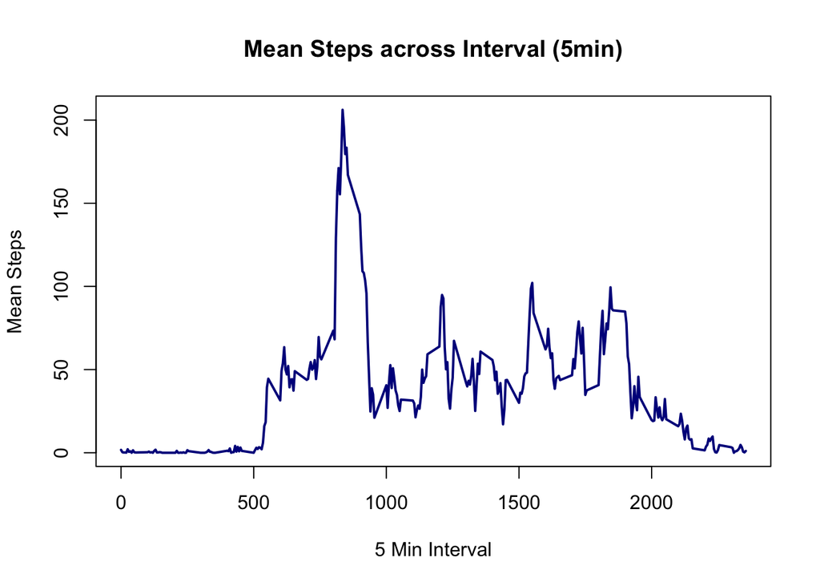

```r
# Create summary data
act.dta.avg <- aggregate(x = act.dta[c("steps")], FUN = mean,
                         by = list(interval = act.dta$interval),
                         na.rm = TRUE)
# Make the plot
plot(x = act.dta.avg$interval, y = act.dta.avg$steps, type = "l", lwd = "2",
     col="darkblue", main = "Mean Steps across Interval (5min)",
     col.main = "black", font.main=2,
     ylab = "Mean Steps", xlab = "5 Min Interval")
```

### Maximum steps

The code below identifies interval with the maximum number of steps.

```r
# Return maximum steps
max(act.dta.avg$steps)
```

```
## [1] 206
```

```r
# Find and display the row.
m.row <- which.max(x = act.dta.avg$steps)
m.row
```

```
## [1] 104
```

```r
# Return the corresponding interval value
act.dta.avg$interval[m.row]
```

```
## [1] 835
```

#### Answer

The maximum value for the mean steps is **206.17** and corresponds to **835** value of the 5-minute interval.